# Master en Big Data. Fundamentos Matemáticos del Análisis de Datos (FMAD).

Tarea 2

Suero, Jesús

Curso 2021-22. Última actualización: 2021-09-24

# Instrucciones preliminares

- Empieza abriendo el proyecto de RStudio correspondiente a tu repositorio personal de la asignatura.
- En todas las tareas tendrás que repetir un proceso como el descrito en la sección *Repite los pasos Creando un fichero Rmarkdown para esta práctica* de la *Práctica00*. Puedes releer la sección *Practicando la entrega de las Tareas* de esa misma práctica para recordar el procedimiento de entrega.

```r
library(tidyverse)
```

# Ejercicio 1. Simulando variables aleatorias discretas.

**Apartado 1:** La variable aleatoria discreta $X1$ tiene esta tabla de densidad de probabilidad (es la variable que se usa como ejemplo en la Sesión ):
$$\begin{array}{|c|c|c|c|c|c|c|}
\hline
\text{valor de }X1 & 0 & 1 & 2 & 3 \\
\hline
\text{Probabilidad de ese valor }P(X = x_i) & \dfrac{64}{125} &
\dfrac{48}{125}& \dfrac{12}{125} & \dfrac{1}{125}\rule{0mm}{6mm} \\[3mm]
\hline
\end{array}$$
Calcula la media y la varianza teóricas de esta variable.

**Respuesta:**

```r
x1 = c(0:3)
p1 = c(64/125, 48/125, 12/125, 1/125)
(media_1 = sum(x1*p1))
```

```
## [1] 0.6
```

```r
(varianza_1 = sum((x1-media_1)^2*p1))
```

```
## [1] 0.48
```

**Apartado 2:** Combina `sample` con `replicate` para simular cien mil muestras de tamaño 10 de esta variable $X1$. Estudia la distribución de las medias muestrales como hemos hecho en ejemplos previos, ilustrando con gráficas la distribución de esas medias muestrales. Cambia después el tamaño de la muestra a 30 y repite el análisis.

**Respuesta:** Análisis para tamaño 10:

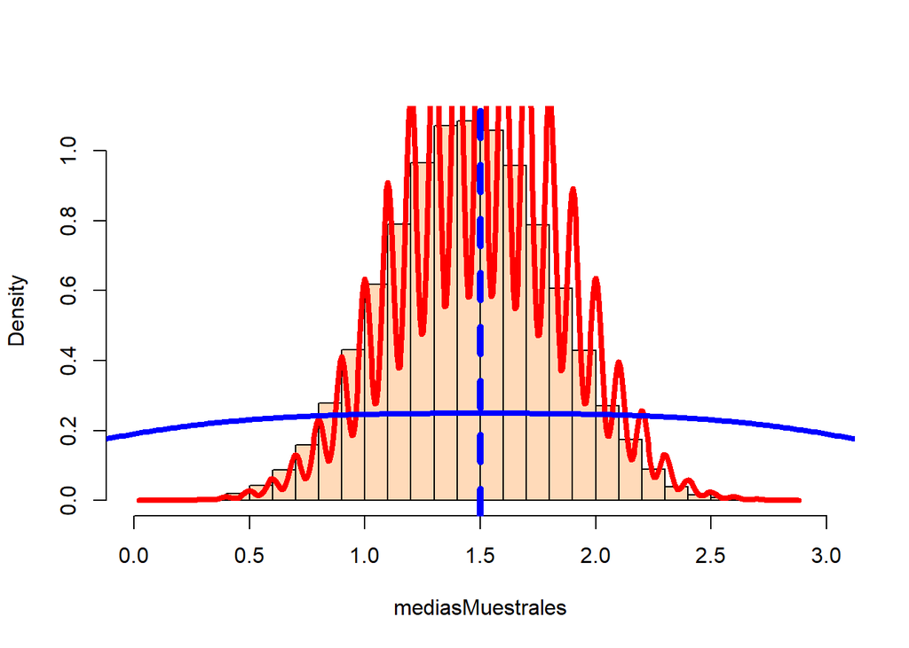

```r
k = 100000
mediasMuestrales = replicate(k, {
  muestra = sample(x1, 10, replace = TRUE)
  mean(muestra)
})
hist(mediasMuestrales, breaks = 20, main="",
     col="peachpuff", probability = TRUE, xlim=range(x1))
lines(density(mediasMuestrales), lwd=4, col="red")
lines(density(x1), lwd=4, col="blue")
abline(v = mean(x1), lty=2, lwd=5, col="blue")
```

Análisis para tamaño 30:

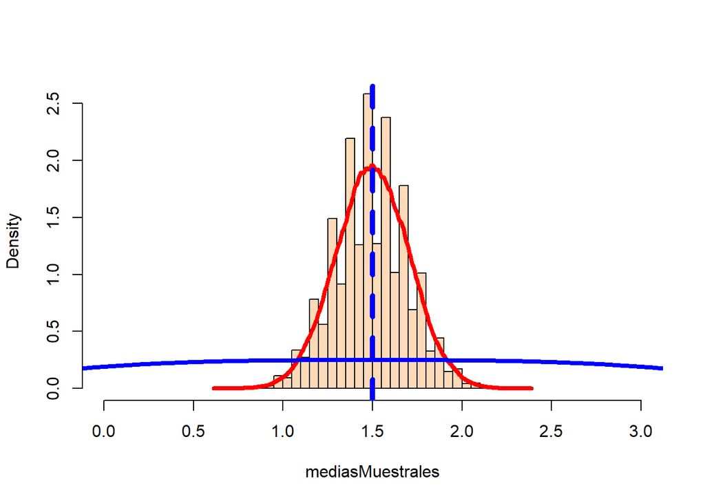

```r
k = 100000
mediasMuestrales = replicate(k, {
  muestra = sample(x1, 30, replace = TRUE)
  mean(muestra)
})
hist(mediasMuestrales, breaks = 30, main="",
     col="peachpuff", probability = TRUE, xlim=range(x1))
lines(density(mediasMuestrales), lwd=4, col="red")
lines(density(x1), lwd=4, col="blue")
abline(v = mean(x1), lty=2, lwd=5, col="blue")
```

**Apartado 3:** La variable aleatoria discreta $X2$ tiene esta tabla de densidad de probabilidad:
$$\begin{array}{|c|c|c|c|c|c|}
\hline
\text{valor de }X2 & 0 & 1 & 2 \\
\hline
\text{Probabilidad de ese valor }P(X = x_i) & \dfrac{1}{2} &
\dfrac{1}{4}& \dfrac{1}{4}\rule{0mm}{6mm} \\[3mm]
\hline
\end{array}$$
Suponemos que $X1$ y $X2$ son independientes. ¿Qué valores puede tomar la suma $X1 + X2$? ¿Cuál es su tabla de probabilidad?

**Respuesta:**

```r
x2 = c(0:2, each=4)
p2 = c(1/4, 1/4, 1/4, 1/4)
p1_2 = c(64/125,48/125,12/125,1/125)*rep(c(1/2,1/4,1/4), each = 4)
suma = x1 + x2
tabla = data.frame(x1, x2, p1_2, suma)

tabla %>%
  group_by(suma) %>%
  summarise(sumaX1X2=sum(p1_2))
```

```
## # A tibble: 4 x 2
##    suma sumaX1X2
##   <dbl>    <dbl>
## 1     0    0.512
## 2     2    0.384
## 3     4    0.096
## 4     7    0.008
```

**Apartado 4:** Calcula la media teórica de la suma $X_1 + X_2$. Después usa `sample` y `replicate` para simular cien mil *valores* de esta variable suma. Calcula la media de esos valores. *Advertencia:* no es el mismo tipo de análisis que hemos hecho en el segundo apartado.

**Respuesta:** Para la media de la suma X1 + X2:

```r
media_2 = sum(x2*p2)
(media_suma = media_1 + media_2)
```

```
## [1] 2.35
```

Calculamos ahora la media de las 100000 simulaciones de la variable suma:

```r
k = 100000
mediasMuestrales = replicate(k, {
  muestra = sample(media_suma, 10, replace = TRUE)
  mean(muestra)
})
mean(mediasMuestrales)
```

```
## [1] 1.500315
```